# Formulas in Excel

Brendan Clarke, NHS Education for Scotland, brendan.clarke2@nhs.scot

03/07/2024

## Welcome

- this session is 🌶 - aimed at Excel beginners
- we’ll get going properly at 15.05
- you’ll need any version of Excel to follow along
- if you can’t access the chat, you might need to join our Teams channel: **tinyurl.com/kindnetwork**
- you can find session materials at **tinyurl.com/kindtrp**

## The KIND network

- a social learning space for staff working with **k**nowledge, **i**nformation, and **d**ata across health, social care, and housing in Scotland
- we offer social support, free training, mentoring, community events, …
- [Teams channel](https://teams.microsoft.com/l/team/19%3AQZ7-PbFVcziG2piHLt1_ifey3I2cwFL0yBuTSS8vVao1%40thread.tacv2/conversations?groupId=106d08f3-9026-40e2-b3c7-87cd87304d58&tenantId=10efe0bd-a030-4bca-809c-b5e6745e499a) / [mailing list](https://forms.office.com/pages/responsepage.aspx?id=veDvEDCgykuAnLXmdF5JmpopIZB9ynRJnrPUHVFccipURjM2NkZJUkhGOFlQRjQxRFhVUTgwT0UwVyQlQCN0PWcu)

## Excel training sessions

| Session | Date | Area | Level |
| --- | --- | --- | --- |
| Lambda formulas in Excel | 13:00-13:30 Mon 15th July 2024 | Excel | 🌶🌶 : **intermediate-level** |
| Lookups in Excel | 13:00-14:30 Thu 1st August 2024 | Excel | 🌶🌶 : **intermediate-level** |
| Relative, absolute, mixed, structured, and R1C1 references in Excel | 15:00-16:00 Thu 8th August 2024 | Excel | 🌶🌶 : **intermediate-level** |

## Where does this fit in?

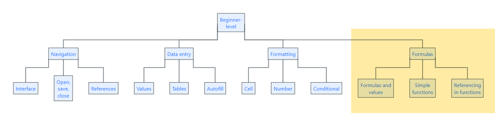

KIND Excel beginner skill tree

- for this session, you’ll need to be familiar with the Excel basics (getting around in Excel, opening/saving/closing files)
- you’ll also need to be familiar with A1 referencing, values, and tables
- we’re going to avoid talking about formatting as much as possible today

## Session outline

- values and formulas
- simple functions
- references in formulas

## Values and formulas

- cells in Excel contain either values, or formulas
- we’ll start with some data derived from [NRS 2022 population estimates](https://www.nrscotland.gov.uk/files//statistics/population-estimates/mid-22/mid-year-pop-est-22-data.xlsx)
- make sure you have the sample data available

## Values

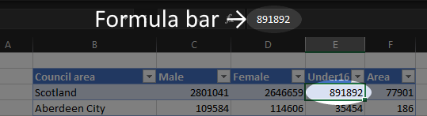

Example value, showing identical cell contents and formula bar contents

- when you enter some data in a cell, we call that a **value**
- values look the same in their cell as in the formula bar

## Formulas

- we can also make a value using a formula
- Excel evaluates/calculates the formula, then displays the result as a value
- in an empty cell, try entering `= 2 + 2`

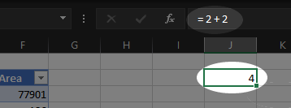

Example formula, showing different cell contents and formula bar contents

## Example formulas

- we can do ordinary arithmetic in formulas `/`, `*`, `-`, `+`…
- you can also try `&` which joins values
  - `= "This number is " & 5`

## Functions

- But most formulas use functions, which are like the verbs of Excel
- Try `= SUM(2, 2)`

## Adding functions

- you can type functions in by name (as above)
- you can also add from the `Formulas` area of the ribbon

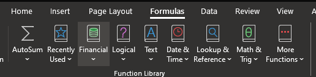

- or you can use the $fx$ button by the formula bar

## Function arguments

- adding a function by $fx$ or the menu brings up the **Function Arguments** interface

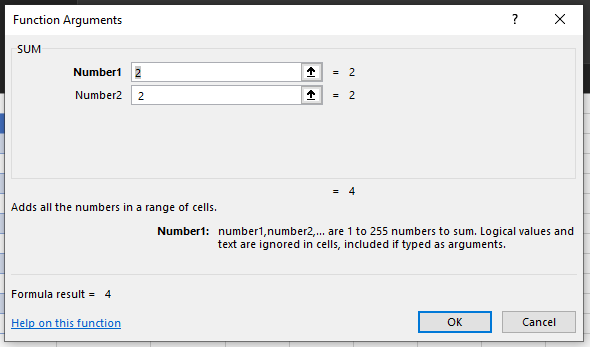

- This is a helpful builder for more complicated functions

## What are arguments?

- **arguments** are the values we supply to a function
  - in `=SUM(2,3)`, the arguments are `2` and `3`
- we separate arguments with a comma `,`
- we need to be sure we’re supplying the right arguments in the right order (this gets described as the **syntax** of a function)
- we also, while we’re on the jargon, say that functions **return** a value so `= SUM(4,3)` will return `7`

## Useful simple functions

- in the same way as `=SUM()`, you can try:
  - `AVERAGE`
  - `MIN` and `MAX`
  - `SUBSTITUTE`
  - `CEILING`
  - `TODAY`
  - `ROUND`

## References in formulas

- mostly, you won’t add values directly into your formulas
- instead, you’ll bring them in from another part of your spreadsheet
- can you use `SUM()` to make a total `Male` + `Female` column in the supplied data?
  - add a header in cell `G2`
  - if needed, extend the table to include your new column
  - in `G3`, enter the formula `= SUM(C3, D3)`
  - then copy down the rows by double-clicking the green fill handle

## Practice

- calculate what percentage of your total population is under 16
- estimate the population density
- find an average area for each council area

## Troubleshooting functions

- `#NAME?` = “I don’t recognise that function name”
- `#VALUE!` = “Your syntax has gone wrong - usually in the wrong order”
- `#REF!` = “I don’t recognise that reference”
- `#DIV/0!` = “You’ve divided by zero”

## Feedback and resources

- please can I ask for some feedback - less than 1 minute, completely anonymous, helps people like you find the right training for them

| Session | Date | Area | Level |
| --- | --- | --- | --- |
| Lambda formulas in Excel | 13:00-13:30 Mon 15th July 2024 | Excel | 🌶🌶 : **intermediate-level** |
| Lookups in Excel | 13:00-14:30 Thu 1st August 2024 | Excel | 🌶🌶 : **intermediate-level** |
| Relative, absolute, mixed, structured, and R1C1 references in Excel | 15:00-16:00 Thu 8th August 2024 | Excel | 🌶🌶 : **intermediate-level** |

[figure not shown]